# ADA HW 3

Lydia Myers

4/17/2021

## Challenge 1

Loading in packages and data:

```r
library(tidyverse)
library(broom)
library(infer)

d<-read_csv("https://raw.githubusercontent.com/difiore/ada-2021-datasets/main/KamilarAndCooperData.csv", col_names=T)
head(d)
```

```
## # A tibble: 6 x 44
##   Scientific_Name   Family   Genus   Species Brain_Size_Speci… Brain_Size_Femal…
##   <chr>             <chr>    <chr>   <chr>               <dbl>             <dbl>
## 1 Allenopithecus_n… Cercopi… Alleno… nigrov…              58.0              53.7
## 2 Allocebus_tricho… Cercopi… Alloce… tricho…              NA                NA
## 3 Alouatta_belzebul Atelidae Alouat… belzeb…              52.8              51.2
## 4 Alouatta_caraya   Atelidae Alouat… caraya               52.6              47.8
## 5 Alouatta_guariba  Atelidae Alouat… guariba              51.7              49.1
## 6 Alouatta_palliata Atelidae Alouat… pallia…              49.9              48.0
## # … with 38 more variables: Brain_size_Ref <chr>, Body_mass_male_mean <dbl>,
## #   Body_mass_female_mean <dbl>, Mass_Dimorphism <dbl>, Mass_Ref <chr>,
## #   MeanGroupSize <dbl>, AdultMales <dbl>, AdultFemale <dbl>,
## #   AdultSexRatio <dbl>, Social_Organization_Ref <chr>,
## #   InterbirthInterval_d <dbl>, Gestation <dbl>, WeaningAge_d <dbl>,
## #   MaxLongevity_m <dbl>, LitterSz <dbl>, Life_History_Ref <chr>,
## #   GR_MidRangeLat_dd <dbl>, Precip_Mean_mm <dbl>, Temp_Mean_degC <dbl>,
## #   AET_Mean_mm <dbl>, PET_Mean_mm <dbl>, Climate_Ref <chr>,
## #   HomeRange_km2 <dbl>, HomeRangeRef <chr>, DayLength_km <dbl>,
## #   DayLengthRef <chr>, Territoriality <dbl>, Fruit <dbl>, Leaves <chr>,
## #   Fauna <chr>, DietRef1 <chr>, Canine_Dimorphism <dbl>,
## #   Canine_Dimorphism_Ref <chr>, Feed <dbl>, Move <dbl>, Rest <dbl>,
## #   Social <dbl>, Activity_Budget_Ref <chr>
```

```r
d<-na.omit(d)
```

Creating linear models for both logged and original data:

```r
d$log_Brain_Size_Species_Mean<-log(d$Brain_Size_Species_Mean)
d$log_WeaningAge_d<-log(d$WeaningAge_d)

r<-lm(WeaningAge_d ~ Brain_Size_Species_Mean, data=d)
logr<-lm(log_WeaningAge_d ~ log_Brain_Size_Species_Mean, data=d)
```

Scatterplots with regression lines and model listed on the plot:

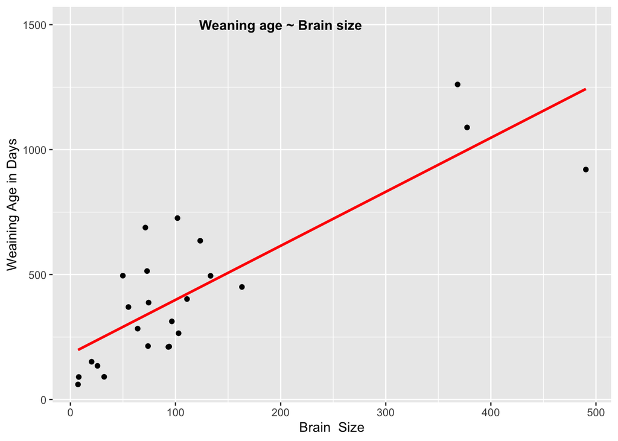

```r
ggplot(d, aes(x=Brain_Size_Species_Mean, y=WeaningAge_d))+geom_point()+
  geom_smooth(method="lm",formula=y~x, se=F, color="red")+
  annotate(geom="text",x=200,y=1500,label="Weaning age ~ Brain size",color="black",fontface=2)+
  labs(y= "Weaining Age in Days", x = "Brain  Size")
```

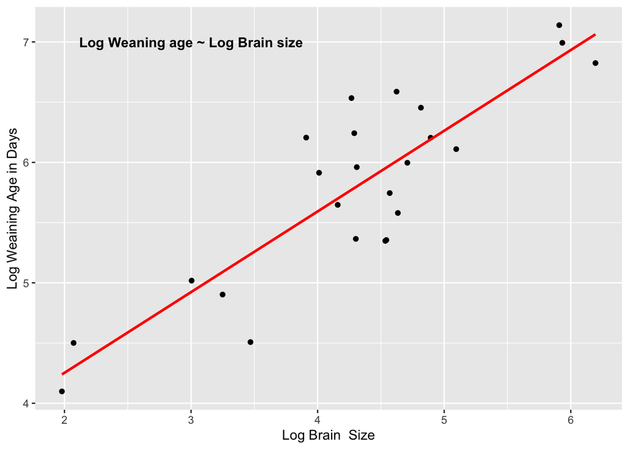

```r
ggplot(d, aes(x=log(Brain_Size_Species_Mean), y=log(WeaningAge_d)))+geom_point()+
  geom_smooth(method="lm",formula=y~x, se=F, color="red")+
  annotate(geom="text",x=3,y=7,label="Log Weaning age ~ Log Brain size",color="black",fontface=2)+
  labs(y= "Log Weaining Age in Days", x = "Log Brain  Size")
```

Evaluating point estimate of the slope, testing hypotheses & listing confidence intervals:

```r
summary(r)
```

```
##
## Call:
## lm(formula = WeaningAge_d ~ Brain_Size_Species_Mean, data = d)
##
## Residuals:
##     Min      1Q  Median      3Q     Max
## -322.56 -130.81  -56.21  111.16  351.28
##
## Coefficients:
##                         Estimate Std. Error t value Pr(>|t|)
## (Intercept)             182.5688    51.6600   3.534  0.00187 **
## Brain_Size_Species_Mean   2.1622     0.3088   7.001 5.01e-07 ***
## ---
## Signif. codes:  0 '***' 0.001 '**' 0.01 '*' 0.05 '.' 0.1 ' ' 1
##
## Residual standard error: 180.7 on 22 degrees of freedom
## Multiple R-squared:  0.6902, Adjusted R-squared:  0.6761
## F-statistic: 49.02 on 1 and 22 DF,  p-value: 5.012e-07
```

```r
summary(logr)
```

```
##
## Call:
## lm(formula = log_WeaningAge_d ~ log_Brain_Size_Species_Mean,
##     data = d)
##
## Residuals:
##      Min       1Q   Median       3Q      Max
## -0.72943 -0.23154 -0.01903  0.27921  0.76209
##
## Coefficients:
##                             Estimate Std. Error t value Pr(>|t|)
## (Intercept)                  2.91298    0.36916   7.891 7.41e-08 ***
## log_Brain_Size_Species_Mean  0.66994    0.08334   8.038 5.45e-08 ***
## ---
## Signif. codes:  0 '***' 0.001 '**' 0.01 '*' 0.05 '.' 0.1 ' ' 1
##
## Residual standard error: 0.4146 on 22 degrees of freedom
## Multiple R-squared:  0.746,  Adjusted R-squared:  0.7345
## F-statistic: 64.62 on 1 and 22 DF,  p-value: 5.451e-08
```

```r
confint(r,'Brain_Size_Species_Mean',level=0.90)
```

```
##                              5 %    95 %
## Brain_Size_Species_Mean 1.631867 2.69244
```

```r
confint(logr,"log_Brain_Size_Species_Mean",level=0.90)
```

```
##                                   5 %      95 %
## log_Brain_Size_Species_Mean 0.5268291 0.8130481
```

For both models, the value of B1 is statistically significantly different from zero, which does not support the null hypothesis that B1=0.

Plotting the 90% confidence and prediction intervals for the models:

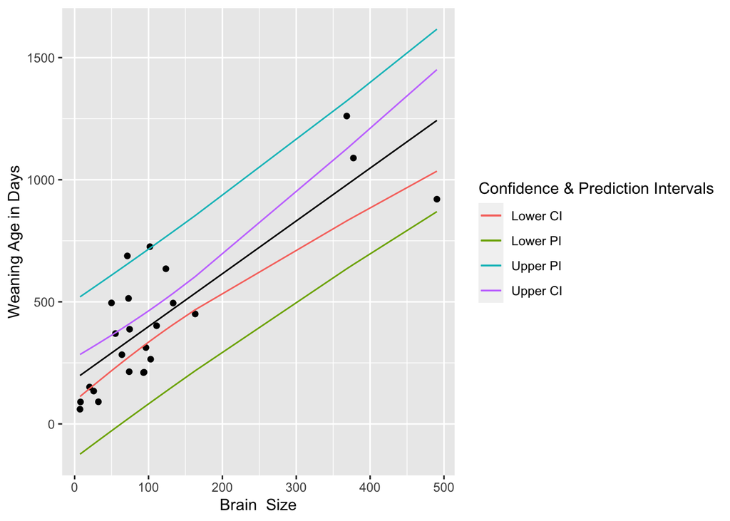

```r
Brain_Size_Species_Mean<-d$Brain_Size_Species_Mean
df <- augment(r, se_fit = TRUE)
alpha<-0.05

#creating confidence intervals
ci <- predict(r, newdata = data.frame(brain_size = d$Brain_Size_Species_Mean),
  interval = "confidence", level = .9)
ci <- data.frame(ci)
ci<-na.omit(ci)
ci <- cbind(df$Brain_Size_Species_Mean, ci)
names(ci) <- c("brain_size", "c.fit", "c.lwr", "c.upr")

#creating prediction intervals
pi <- predict(r, newdata = data.frame(brain_size = d$Brain_Size_Species_Mean),
              interval = "prediction", level = .9)
pi <- data.frame(pi)
pi<-na.omit(pi)
pi <- cbind(df$Brain_Size_Species_Mean, pi)
names(pi) <- c("brain_size", "p.fit", "p.lwr", "p.upr")

#plotting
ggplot(data = df, aes(x = Brain_Size_Species_Mean, y = WeaningAge_d))+
  geom_point() + geom_line(data=ci, aes(x=Brain_Size_Species_Mean, y=c.fit))+
  geom_line(data=ci, aes(x=Brain_Size_Species_Mean, y=c.lwr, color="blue"))+
  geom_line(data=ci, aes(x=Brain_Size_Species_Mean, y=c.upr, color="red"))+
  geom_line(data = pi, aes(x = brain_size, y = p.lwr, color="darkblue"))+
  geom_line(data = pi, aes(x = brain_size, y = p.upr, color = "darkred"))+
  scale_color_discrete(name = "Confidence & Prediction Intervals",
  labels = c("Lower CI", "Lower PI", "Upper PI", "Upper CI"))+
  labs(y= "Weaning Age in Days", x = "Brain  Size")
```

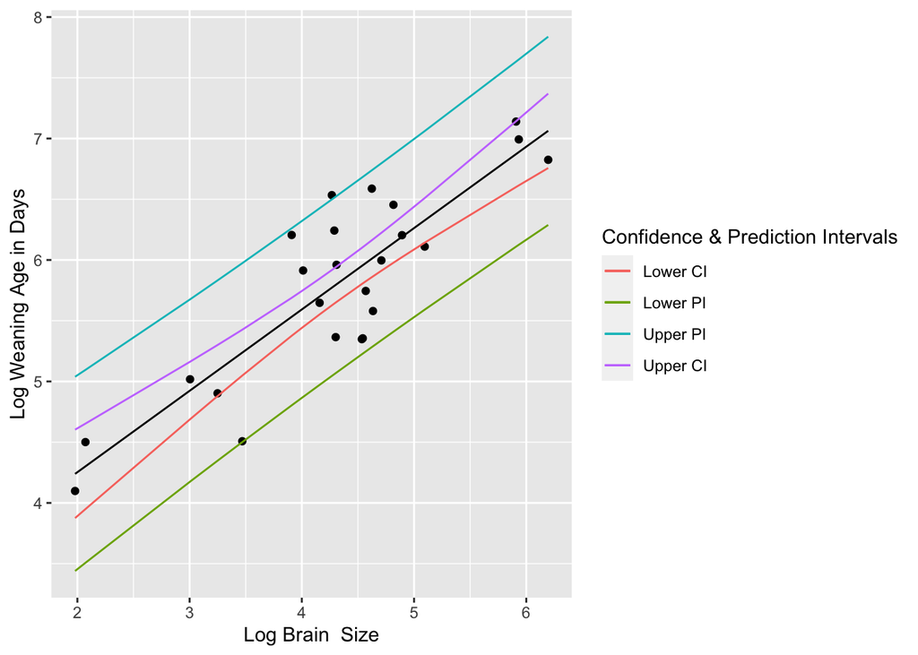

```r
#doing the same for tthe logged stuff
log_Brain_Size_Species_Mean<-log(d$Brain_Size_Species_Mean)
df <- augment(logr, se_fit = TRUE)

#creating confidence intervals
ci <- predict(logr, newdata = data.frame(log_brain_size = log(d$Brain_Size_Species_Mean)),
              interval = "confidence", level = .9)
ci <- data.frame(ci)
ci<-na.omit(ci)
ci <- cbind(df$log_Brain_Size_Species_Mean, ci)
names(ci) <- c("log_brain_size", "c.fit", "c.lwr", "c.upr")

#creating prediction intervals
pi <- predict(logr, newdata = data.frame(log_brain_size = log(d$Brain_Size_Species_Mean)),
              interval = "prediction", level = .9)
pi <- data.frame(pi)
pi<-na.omit(pi)
pi <- cbind(df$log_Brain_Size_Species_Mean, pi)
names(pi) <- c("log_brain_size", "p.fit", "p.lwr", "p.upr")

#plotting
ggplot(data = df, aes(x = log_Brain_Size_Species_Mean, y = log_WeaningAge_d))+
  geom_point() + geom_line(data=ci, aes(x=log_Brain_Size_Species_Mean, y=c.fit))+
  geom_line(data=ci, aes(x=log_Brain_Size_Species_Mean, y=c.lwr, color="blue"))+
  geom_line(data=ci, aes(x=log_Brain_Size_Species_Mean, y=c.upr, color="red"))+
  geom_line(data = pi, aes(x = log_brain_size, y = p.lwr, color="darkblue"))+
  geom_line(data = pi, aes(x = log_brain_size, y = p.upr, color = "darkred"))+
  scale_color_discrete(name = "Confidence & Prediction Intervals",
  labels = c("Lower CI", "Lower PI", "Upper PI", "Upper CI"))+
  labs(y= "Log Weaning Age in Days", x = "Log Brain  Size")
```

```r
predict(r,newdata = data.frame(Brain_Size_Species_Mean = 750),interval = "prediction", level = 0.90)
```

```
##        fit      lwr      upr
## 1 1804.184 1342.696 2265.672
```

I do not trust the model to provide an accurate prediction for a brain of 750 gm, as this size is much larger than the data the model used to create the prediction.

I believe the logged model is more accurate, because the data fits the regression line better.

## Challenge 2

Running a regression on mean group size and body mass, and listing the coefficients:

```r
d$log_MeanGroupSize<-log(d$MeanGroupSize)
d$log_Body_mass_female_mean<-log(d$Body_mass_female_mean)

r<-lm(log_MeanGroupSize~log_Body_mass_female_mean, data=d)
r$coefficients
```

```
##               (Intercept) log_Body_mass_female_mean
##                 1.1426138                 0.1512023
```

Generating a bootstrap sampling distribution for each beta coefficient:

```r
#bootstrap coefficients
set.seed(1)
bootVals<-data.frame(boot_slope = 1:1000, boot_intercept = 1:1000)

for (i in 1:1000){
  s<-sample_n(d, size=nrow(d), replace=T)
  bootr<-lm(log_MeanGroupSize~log_Body_mass_female_mean, data=s)
  vals<-bootr$coefficients
  bootVals$boot_slope[[i]]<-vals[1]
  bootVals$boot_intercept[[i]]<-vals[2]
}
```

Plotting histograms:

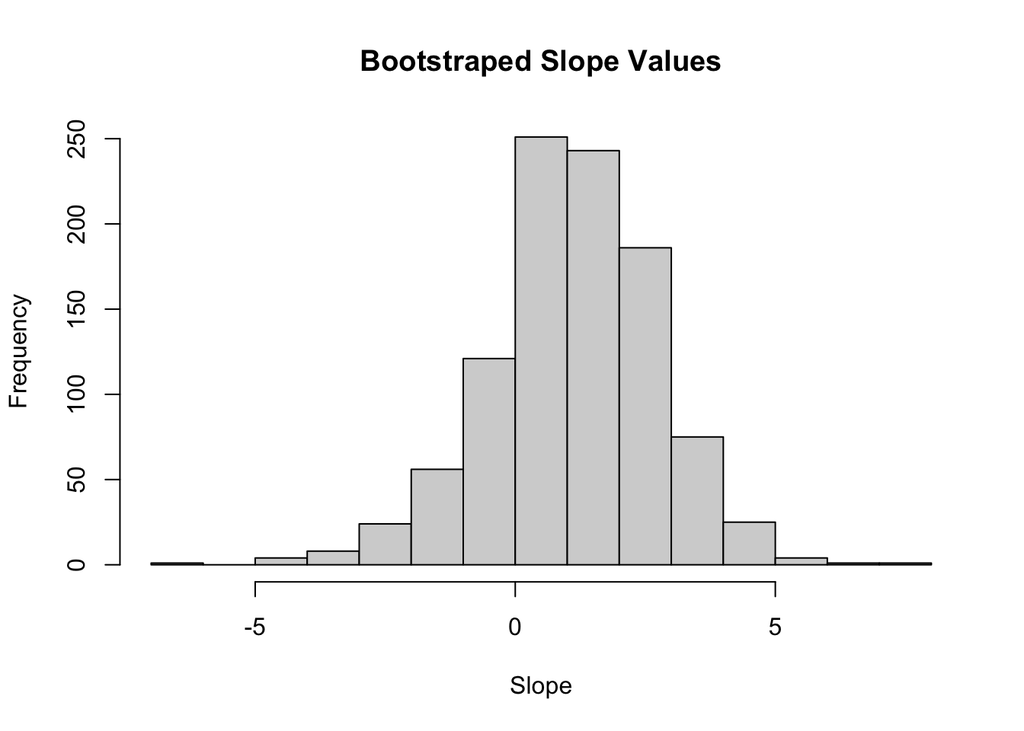

```r
hist(bootVals$boot_slope, main = "Bootstraped Slope Values", xlab = "Slope", breaks = 15)
```

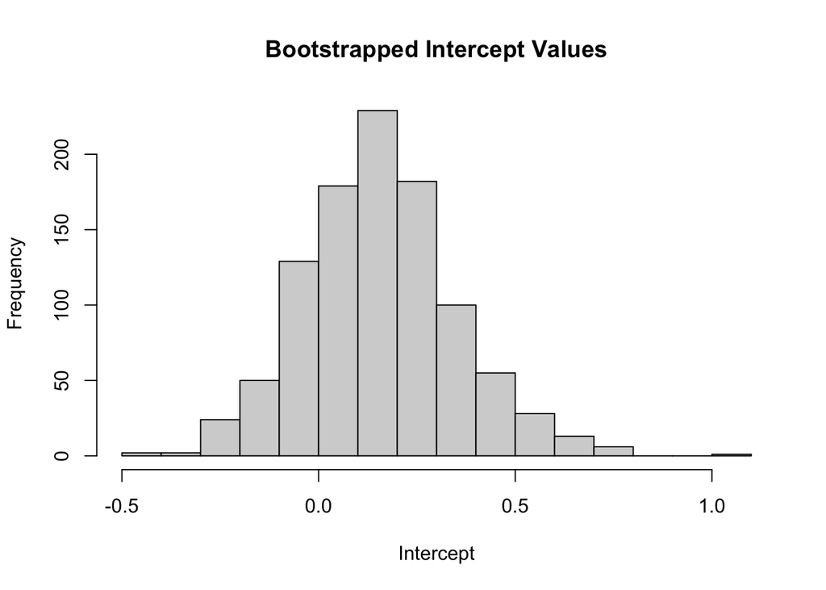

```r
hist(bootVals$boot_intercept, main = "Bootstrapped Intercept Values", xlab = "Intercept", breaks = 15)
```

Getting standard errors:

```r
#getting bootstrap SEs
slope_se<-sd(bootVals$boot_slope)
intercept_se<-sd(bootVals$boot_intercept)
SE<-data.frame(Slope = slope_se, Intercept = intercept_se, row.names = "SE")
SE
```

```
##       Slope Intercept
## SE 1.618338 0.1938892
```

```r
#getting SE fro original model
summary(r)
```

```
##
## Call:
## lm(formula = log_MeanGroupSize ~ log_Body_mass_female_mean, data = d)
##
## Residuals:
##      Min       1Q   Median       3Q      Max
## -2.03970 -0.57556  0.01865  0.59171  1.48135
##
## Coefficients:
##                           Estimate Std. Error t value Pr(>|t|)
## (Intercept)                 1.1426     1.4353   0.796    0.435
## log_Body_mass_female_mean   0.1512     0.1637   0.923    0.366
##
## Residual standard error: 0.9815 on 22 degrees of freedom
## Multiple R-squared:  0.03731,    Adjusted R-squared:  -0.006447
## F-statistic: 0.8527 on 1 and 22 DF,  p-value: 0.3658
```

The SE values from the bootstrap are similar to those from the lm() function, but not entirely the same.

Getting CIs:

```r
#getting CIs from bootstrap
slope_lower<-quantile(bootVals$boot_slope, (.05/2))
slope_upper<-quantile(bootVals$boot_slope, (1-.05/2))
intercept_lower<-quantile(bootVals$boot_intercept, (.05/2))
intercept_upper<-quantile(bootVals$boot_intercept, (1-.05/2))

CI<-data.frame(Lower = c(slope_lower, intercept_lower), Upper = c(slope_upper, intercept_upper),
               row.names = c("Intercept", "Slope"))

CI
```

```
##                Lower    Upper
## Intercept -2.4068010 4.102211
## Slope     -0.2089307 0.575704
```

```r
#getting CIs from original model
confint(r, level=.95)
```

```
##                               2.5 %    97.5 %
## (Intercept)               -1.834085 4.1193127
## log_Body_mass_female_mean -0.188385 0.4907895
```

Values are again very similar, but not exactly the same. Values are more similar for CIs than SEs.

## Challenge 3

Creating the function:

```r
boot_lm<-function (d, model, conf.level=0.95, reps=1000){
  df<-data.frame(coefficients = c(0,0), SE = c(0,0), lowerCI = c(0,0), upperCI = c(0,0),
        bootcoeff = c(mean(bootVals[,2]), mean(bootVals[,1])), bootSE = c(0,0),
        bootlowerCI = c(0,0), bootupperCI = c(0,0), row.names=c("Intercept", "Slope"))
  r<-lm(model, data=d)
  tidyr<-tidy(r)
  df$coefficients[1]<-tidyr[1,2]
  df$coefficients[2]<-tidyr[2,2]
  df$SE[1]<-tidyr[1,3]
  df$SE[2]<-tidyr[2,3]
  CI<-confint(r, level=conf.level)
  df$lowerCI[1]<-CI[1,1]
  df$lowerCI[2]<-CI[2,1]
  df$upperCI[1]<-CI[1,2]
  df$upperCI[2]<-CI[2,2]
  set.seed(1)
  bootVals<-data.frame(boot_slope = 1:1000, boot_intercept = 1:1000)
  for (i in 1:reps){
    s<-sample_n(d, size=nrow(d), replace=T)
    bootr<-lm(model, data=s)
    vals<-bootr$coefficients
    bootVals$boot_slope[[i]]<-vals[1]
    bootVals$boot_intercept[[i]]<-vals[2]}
  slope_se<-sd(bootVals$boot_slope)
  intercept_se<-sd(bootVals$boot_intercept)
  df$bootSE[1]<-intercept_se
  df$bootSE[2]<-slope_se
  slope_lower<-quantile(bootVals$boot_slope, ((1-conf.level)/2))
  slope_upper<-quantile(bootVals$boot_slope, (1-(1-conf.level)/2))
  intercept_lower<-quantile(bootVals$boot_intercept, ((1-conf.level)/2))
  intercept_upper<-quantile(bootVals$boot_intercept, (1-(1-conf.level)/2))
  df$bootlowerCI[1]<-intercept_lower
  df$bootlowerCI[2]<-slope_lower
  df$bootupperCI[1]<-intercept_upper
  df$bootupperCI[2]<-slope_upper
  return(df)

}
```

Running the function on three linear models:

```r
boot_lm(d=d, model=log(MeanGroupSize) ~ log(Body_mass_female_mean))
```

```
##           coefficients        SE   lowerCI   upperCI bootcoeff    bootSE
## Intercept     1.142614  1.435333 -1.834085 4.1193127 0.1576102 0.1938892
## Slope        0.1512023 0.1637454 -0.188385 0.4907895 1.0899292 1.6183380
##           bootlowerCI bootupperCI
## Intercept  -0.2089307    0.575704
## Slope      -2.4068010    4.102211
```

```r
boot_lm(d=d, model=log(DayLength_km) ~ log(Body_mass_female_mean))
```

```
##           coefficients        SE    lowerCI   upperCI bootcoeff    bootSE
## Intercept   -0.3925435  1.053627 -2.5776328 1.7925459 0.1576102 0.1209541
## Slope       0.04843659 0.1201997 -0.2008424 0.2977156 1.0899292 1.0075952
##           bootlowerCI bootupperCI
## Intercept  -0.1666025   0.3236364
## Slope      -2.5897161   1.4408520
```

```r
boot_lm(d=d, model=log(DayLength_km) ~ log(Body_mass_female_mean) + log(MeanGroupSize))
```

```
##           coefficients        SE    lowerCI   upperCI bootcoeff     bootSE
## Intercept   -0.7355628 0.9981878 -2.8114080 1.3402824 0.1576102 0.09975566
## Slope      0.003044782 0.1144246 -0.2349141 0.2410037 1.0899292 0.98508115
##           bootlowerCI bootupperCI
## Intercept  -0.1744217    0.213337
## Slope      -2.7392283    1.055050
```